# Algoritmos

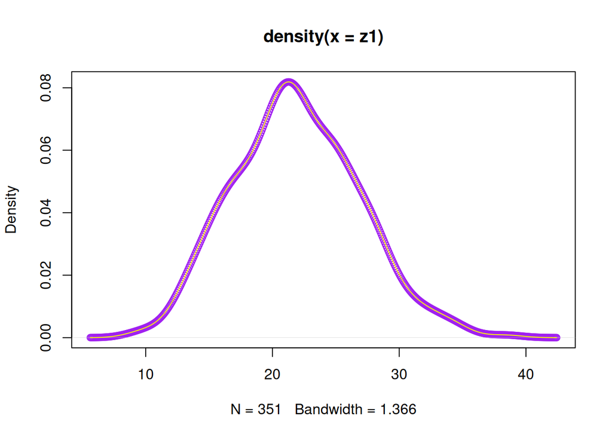

```r
plot(density(z1),type="p",col="purple")
lines(density(z1),col="yellow")
```

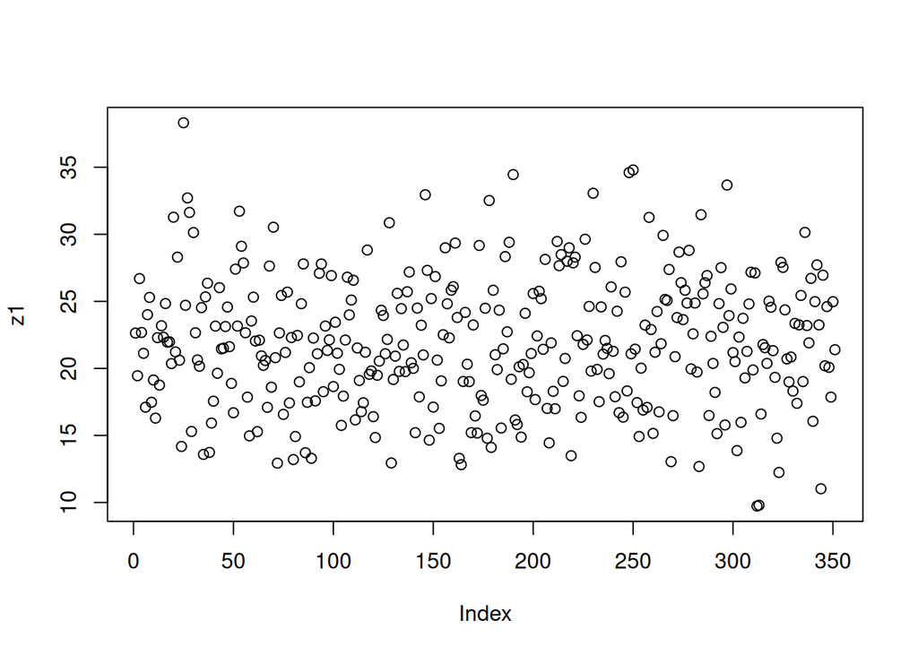

```r
plot(z1)
```

```r
w1<-length(z1)
w1
```

```
## [1] 351
```

```r
x1<-(500:850)
x1
```

```
##   [1] 500 501 502 503 504 505 506 507 508 509 510 511 512 513 514 515 516 517
##  [19] 518 519 520 521 522 523 524 525 526 527 528 529 530 531 532 533 534 535
##  [37] 536 537 538 539 540 541 542 543 544 545 546 547 548 549 550 551 552 553
##  [55] 554 555 556 557 558 559 560 561 562 563 564 565 566 567 568 569 570 571
##  [73] 572 573 574 575 576 577 578 579 580 581 582 583 584 585 586 587 588 589
##  [91] 590 591 592 593 594 595 596 597 598 599 600 601 602 603 604 605 606 607
## [109] 608 609 610 611 612 613 614 615 616 617 618 619 620 621 622 623 624 625
## [127] 626 627 628 629 630 631 632 633 634 635 636 637 638 639 640 641 642 643
## [145] 644 645 646 647 648 649 650 651 652 653 654 655 656 657 658 659 660 661
## [163] 662 663 664 665 666 667 668 669 670 671 672 673 674 675 676 677 678 679
## [181] 680 681 682 683 684 685 686 687 688 689 690 691 692 693 694 695 696 697
## [199] 698 699 700 701 702 703 704 705 706 707 708 709 710 711 712 713 714 715
## [217] 716 717 718 719 720 721 722 723 724 725 726 727 728 729 730 731 732 733
## [235] 734 735 736 737 738 739 740 741 742 743 744 745 746 747 748 749 750 751
## [253] 752 753 754 755 756 757 758 759 760 761 762 763 764 765 766 767 768 769
## [271] 770 771 772 773 774 775 776 777 778 779 780 781 782 783 784 785 786 787
## [289] 788 789 790 791 792 793 794 795 796 797 798 799 800 801 802 803 804 805
## [307] 806 807 808 809 810 811 812 813 814 815 816 817 818 819 820 821 822 823
## [325] 824 825 826 827 828 829 830 831 832 833 834 835 836 837 838 839 840 841
## [343] 842 843 844 845 846 847 848 849 850
```

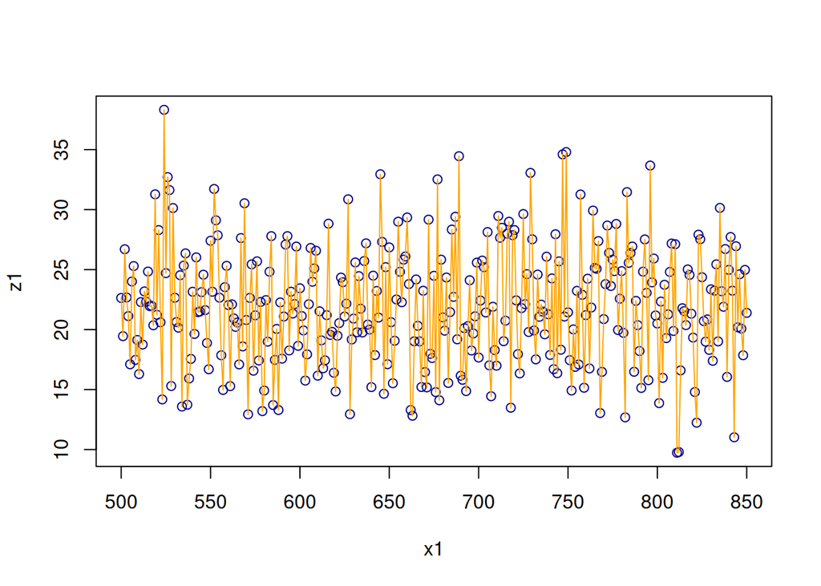

```r
plot(x1, z1, col="darkblue")
lines(x1, z1, type="l", col="orange")
```

# Clase 8 de Abril ## Ejercicio 1 de algoritmos **Consigna 1:** Las últimas 3 cifras de mi DNI son 900. Crear una variable que tenga ese número.

```r
DNI=900
```

**Consigna 2:** Crear un vector que tenga todos los números desde el 1 hasta el 900.

```r
for(i in 1:900)
print(1:i)
```

```
## [1] 1
## [1] 1 2
## [1] 1 2 3
## [1] 1 2 3 4
## [1] 1 2 3 4 5
## [1] 1 2 3 4 5 6
## [1] 1 2 3 4 5 6 7
## [1] 1 2 3 4 5 6 7 8
## [1] 1 2 3 4 5 6 7 8 9
##  [1]  1  2  3  4  5  6  7  8  9 10
##  [1]  1  2  3  4  5  6  7  8  9 10 11
##  [1]  1  2  3  4  5  6  7  8  9 10 11 12
##  [1]  1  2  3  4  5  6  7  8  9 10 11 12 13
##  [1]  1  2  3  4  5  6  7  8  9 10 11 12 13 14
##  [1]  1  2  3  4  5  6  7  8  9 10 11 12 13 14 15
```

[output cut: 22857 more lines]

```r
secuencia_DNI <- c()
for(i in 1:900){
secuencia_DNI <- c(secuencia_DNI, i)
}
```

## Ejercicio 2

**Consigna 3:** Calcular la suma de todos los valores del vector secuencia_DNI

```r
Total<-0
Valor_final<-length(secuencia_DNI)
for(i in 1:Valor_final){
Total<-Total+i
}
Total
```

```
## [1] 405450
```

```r
print(Total)
```

```
## [1] 405450
```

## Ejercicio 3

```r
system.time(for(i in 1:100) mad(runif(1000)))
```

```
##    user  system elapsed
##   0.012   0.001   0.013
```

```r
require(stats)
system.time(for(i in 1:100) mad(runif(1000)))
```

```
##    user  system elapsed
##   0.012   0.000   0.012
```

```r
require(stats)
DNI= 900
secuencia= 1:DNI
total <- 0
Valor_final <- length(secuencia)
for (i in 1:Valor_final){
total <- total + secuencia[i]
}
print(total)
```

```
## [1] 405450
```

```r
sleep_for_a_minute <- function() { Sys.sleep(14) }
start_time <- Sys.time()
sleep_for_a_minute()
end_time <- Sys.time()
end_time- start_time
```

```
## Time difference of 14.01522 secs
```

## Ejercicio 6: **Comparación de performance con system.time()**

```r
system.time({
A <- numeric(50000)
for (i in 1:50000) {
A[i] <- i * 2
}
})
```

```
##    user  system elapsed
##   0.006   0.000   0.011
```

```r
system.time({
B <- seq(from = 2, to = 100000, by = 2)
})
```

```
##    user  system elapsed
##       0       0       0
```

## Biblioteca tictoc

El uso de una biblioteca en R consiste en incorporar un conjunto de funciones adicionales que amplían las capacidades del lenguaje. Estas bibliotecas contienen procedimientos previamente desarrollados que permiten realizar tareas específicas de manera más sencilla y eficiente. Para poder utilizarlas, primero es necesario instalarlas mediante el comando install.packages(), lo que descarga el paquete al entorno de trabajo. Luego, se debe cargar con library(), paso que habilita sus funciones para ser utilizadas en la sesión actual. En el caso de la biblioteca tictoc, su finalidad es medir el tiempo de ejecución de un bloque de código. Esta incorpora las funciones tic() y toc(), que actúan como un cronómetro: la primera inicia la medición y la segunda la finaliza mostrando el tiempo transcurrido. Estas funciones son similares a las utilizadas en Octave o Matlab, manteniendo una lógica de uso sencilla y familiar. Si bien R dispone de herramientas propias para medir tiempos, como system.time(), la biblioteca tictoc ofrece una alternativa más cómoda y clara, especialmente cuando se desea evaluar y comparar el rendimiento de distintos procedimientos. De este modo, facilita el análisis de eficiencia del código y mejora la organización del trabajo.

```r
library(tictoc)
tic("sleeping")
A<-20
print("dormire una siestita...")
## [1] "dormire una siestita..."
Sys.sleep(2)
print("...suena el despertador")
## [1] "...suena el despertador"
toc()
```

[output not shown]

## Biblioteca rbenchmark

La función benchmark del paquete rbenchmark se describe en su documentación como un contenedor sencillo alrededor de la función base system.time() de R. Esto significa que internamente utiliza el mismo mecanismo para medir el tiempo de ejecución, pero lo presenta de una manera más práctica y organizada para el usuario. Aunque system.time() permite medir cuánto tarda una expresión en ejecutarse, su uso repetido puede volverse poco cómodo cuando se desean comparar varias expresiones o realizar múltiples repeticiones de cada una. En cambio, benchmark simplifica este proceso, ya que permite evaluar varias expresiones dentro de una sola llamada, indicando además cuántas repeticiones se desean realizar. Otra ventaja importante es que los resultados obtenidos se devuelven en forma de data frame, lo que facilita su lectura, comparación y posterior análisis. De este modo, la función no solo automatiza la medicición de tiempos, sino que también organiza la información de manera clara y estructurada, aportando mayor comodidad y eficiencia al trabajo de evaluación de rendimiento en R. ## Implementación de una serie Fibonachi o Fibonacci En matemáticas, la sucesión de Fibonacci es una sucesión infinita de números naturales que comienza de la siguiente manera: 0, 1, 1, 2, 3, 5, 8, 13, 21, 34, 55, 89, 144, 233, … La característica principal de esta sucesión es que, a partir de los dos primeros términos (0 y 1), cada número se obtiene sumando los dos anteriores. Los elementos que forman esta sucesión se denominan números de Fibonacci. Esta sucesión fue introducida en Europa por Leonardo de Pisa, matemático italiano del siglo XIII, más conocido como Fibonacci, en su obra Liber Abaci. Aunque ya era conocida en matemáticas orientales, su difusión en Europa se debe a este autor. La sucesión de Fibonacci posee numerosas aplicaciones en diversas áreas, como la matemática, la informática, la teoría de juegos e incluso en fenómenos naturales y modelos de crecimiento. Su importancia radica tanto en su sencillez como en las múltiples propiedades y relaciones que presenta dentro del estudio de los números. **Consigna 8:** ¿Cuantas iteraciones se necesitan para generar un número de la serie mayor que 20 ? Además mostrar la serie de Fibonacci hasta el número obtenido anteriormente.

```r
# Inicialización
a <- 0
b <- 1
serie <- c(a, b)  # guardamos la serie
contador <- 2
# ya tenemos 2 términos
# Generar hasta superar 20
while (b <= 20) {
siguiente <- a + b
a <- b
b <- siguiente
serie <- c(serie, b)  # agregamos a la serie
contador <- contador + 1
}
# Resultados
cat("Cantidad de iteraciones:", contador, "\n")
```

```
## Cantidad de iteraciones: 9
```

```r
cat("Primer número mayor a 20:", b, "\n")
```

```
## Primer número mayor a 20: 21
```

```r
cat("Serie de Fibonacci hasta ese número:\n")
```

```
## Serie de Fibonacci hasta ese número:
```

```r
print(serie)
```

```
## [1]  0  1  1  2  3  5  8 13 21
```

**Consigna 9:** Compara la performance de ordenación del método burbuja vs el método sort de R. Usar método microbenchmark para una muestra de tamaño 20.000

```r
# Instalar paquete
if (!require(microbenchmark)) {
install.packages("microbenchmark")
library(microbenchmark)
}
# Generar muestra
set.seed(123)
n <- 20000
vector <- sample(1:100000, n, replace = TRUE)
#Implementación de ordenamiento burbuja
bubble_sort <- function(x) {
n <- length(x)
for (i in 1:(n-1)) {
for (j in 1:(n-i)) {
if (x[j] > x[j+1]) {
temp <- x[j]
x[j] <- x[j+1]
x[j+1] <- temp
}
}
}
return(x)
}
#Benchmark (OJO: burbuja es muy lento)
resultado <- microbenchmark(
burbuja = bubble_sort(vector),
sort_R = sort(vector),
times = 5
)
print(resultado)
```

```
## Unit: microseconds
##     expr          min          lq         mean       median          uq
##  burbuja 21348781.518 22515205.90 2.284360e+07 23198237.757 23280305.19
##   sort_R      616.511      628.94 7.482904e+02      699.911      745.55
##          max neval
##  23875448.65     5
##      1050.54     5
```

## La penitencia de Newton

Algunos historiadores relatan que Isaac Newton, durante su etapa escolar, tuvo un maestro sumamente estricto que exigía absoluta atención en clase. Ante cualquier distracción o falta de disciplina, imponía como castigo una tarea particularmente tediosa: calcular para el día siguiente la suma de todos los números desde 1 hasta un número elegido al azar. A simple vista, esta consigna implicaba realizar largas sumas parciales, una por una, lo que podía demandar horas de trabajo. El profesor, precavido, ya tenía resueltos estos cálculos y los llevaba anotados en un cuaderno voluminoso, similar en utilidad a una tabla de logaritmos, que transportaba cuidadosamente en su portafolio. La anécdota cobra relevancia porque, según la tradición, el joven Newton habría encontrado una forma más rápida y elegante de realizar esas sumas, descubriendo un patrón que permitía obtener el resultado sin necesidad de sumar término por término. Más allá de su veracidad histórica, el relato ilustra cómo la observación y el razonamiento pueden transformar una tarea repetitiva en un problema matemático con una solución general. **Consigna 10:** Desarrolla dos algoritmos que hagan este trabajo, por ejemplo para sumar desde 1 hasta 1*1010 y verifica cuál de los dos es más eficiente.

```r
#Algoritmo 1: suma con for (iterativo)
n <- 1010
suma1 <- 0
for (i in 1:n){
suma1 <- suma1 + i
}
suma1
```

```
## [1] 510555
```

```r
#Complejidad:O(n)(suma uno por uno)
#Algoritmo 2: fórmula matemática (Gauss)
n <- 1010
suma2 <- n * (n + 1) / 2
suma2
```

```
## [1] 510555
```

```r
#Complejidad:O(1)(una sola operación)
#Comparación de eficiencia:medir tiempos con system.time():
# Método 1
system.time({
suma1 <- 0
for (i in 1:1010){
suma1 <- suma1 + i
}
})
```

```
##    user  system elapsed
##   0.002   0.000   0.002
```

```r
# Método 2
system.time({
suma2 <- 1010 * (1010 + 1) / 2
})
```

```
##    user  system elapsed
##       0       0       0
```

```r
# Librerías necesarias
library(ggplot2)
library(cluster)

# 1. Simulación de datos de sensores (Normalizados)
set.seed(123)
vibracion <- c(rnorm(100, 2, 0.5), rnorm(100, 5, 0.8), rnorm(100, 8, 0.6))
temperatura <- c(rnorm(100, 30, 5), rnorm(100, 50, 7), rnorm(100, 70, 5))
df <- data.frame(vibracion, temperatura)

# Escalamiento (Paso crítico mencionado en tu texto)
df_scaled <- scale(df)

# 2. Ejecución de K-means (k=3)
fit <- kmeans(df_scaled, centers = 3, nstart = 25)
df$cluster <- as.factor(fit$cluster)

# 3. Medición de Performance: Coeficiente de Silueta
sil <- silhouette(fit$cluster, dist(df_scaled))
avg_sil <- mean(sil[, 3])
cat("El coeficiente de silueta promedio es:", avg_sil)
```

```
## El coeficiente de silueta promedio es: 0.6808356
```

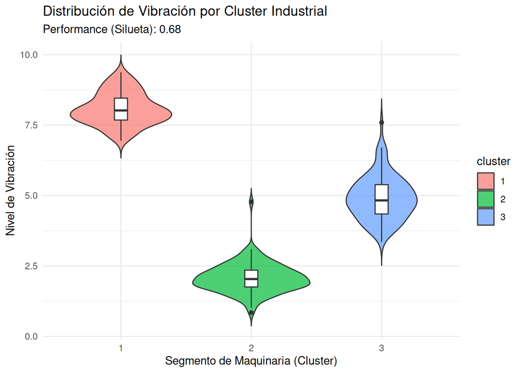

```r
# 4. Visualización con Gráfico de Violín
ggplot(df, aes(x = cluster, y = vibracion, fill = cluster)) +
  geom_violin(trim = FALSE, alpha = 0.7) +
  geom_boxplot(width = 0.1, fill = "white") +
  labs(title = "Distribución de Vibración por Cluster Industrial",
       subtitle = paste("Performance (Silueta):", round(avg_sil, 2)),
       x = "Segmento de Maquinaria (Cluster)",
       y = "Nivel de Vibración") +
  theme_minimal()
```

## Ejercicio Matrices e Inversa

```r
dni_val <- 546

datos <- c(dni_val, 10, 15,
           2, 5, 8,
           7, 1, 9)

A <- matrix(datos, nrow = 3, ncol = 3, byrow = TRUE)

cat("### Matriz Original (A):\n")
```

```
## ### Matriz Original (A):
```

```r
print(A)
```

```
##      [,1] [,2] [,3]
## [1,]  546   10   15
## [2,]    2    5    8
## [3,]    7    1    9
```

```r
determinante <- det(A)
cat("\nDeterminante de la matriz:", determinante, "\n")
```

```
##
## Determinante de la matriz: 20087
```

```r
if (determinante != 0) {
  A_inversa <- solve(A)
  cat("\n### Matriz Inversa (A^-1):\n")
  print(A_inversa)

  identidad <- round(A %*% A_inversa, 2)
  cat("\n### Verificación (A * A^-1 = Identidad):\n")
  print(identidad)
} else {
  cat("\nLa matriz es singular y no tiene inversa.")
}
```

```
##
## ### Matriz Inversa (A^-1):
##              [,1]         [,2]          [,3]
## [1,]  0.001841987 -0.003733758  0.0002489172
## [2,]  0.001891771  0.239408573 -0.2159605715
## [3,] -0.001642854 -0.023696918  0.1349131279
##
## ### Verificación (A * A^-1 = Identidad):
##      [,1] [,2] [,3]
## [1,]    1    0    0
## [2,]    0    1    0
## [3,]    0    0    1
```